# Session 5 — Logistic Regression

Odds · why we exponentiate · likelihood · pseudo-R² · ROC · OR vs PR · Topic 8 · Lab 5

Community Medicine Workshop

## Where we are

- Sessions 2–4: **continuous** outcome → linear regression
- Today: **binary** outcome (hypertension yes/no) → **logistic regression**
- By the end you can:
  - explain **odds, log-odds** and **why we exponentiate** β into an OR
  - build crude and adjusted ORs with CIs
  - compare models by **likelihood ratio test** and **AIC**; read **pseudo-R²** honestly
  - judge **calibration** and **discrimination** (Hosmer–Lemeshow, ROC/AUC)
  - know when the **OR overstates** the prevalence ratio

# A binary outcome

## Hypertension in our survey

```r
ncd |> count(htn_f) |> mutate(percent = round(100 * n / sum(n), 1))
```

```
# A tibble: 2 × 3
  htn_f      n percent
  <fct>  <int>   <dbl>
1 No HTN   408      68
2 HTN      192      32
```

**32%** of adults are hypertensive — a **common** outcome. (Remember this for the OR vs PR discussion.)

## Why not just use linear regression?

```r
lpm <- lm(htn ~ age + salt_g + bmi + sex, data = cc)     # "linear probability model"
range(fitted(lpm))
```

```
[1] -0.3403238  0.9396895
```

```r
sum(fitted(lpm) < 0)                                      # people with a negative "probability"
```

```
[1] 50
```

Fit a straight line to a 0/1 outcome and some people get a **negative “probability”**.

## A straight line leaves the 0–1 range

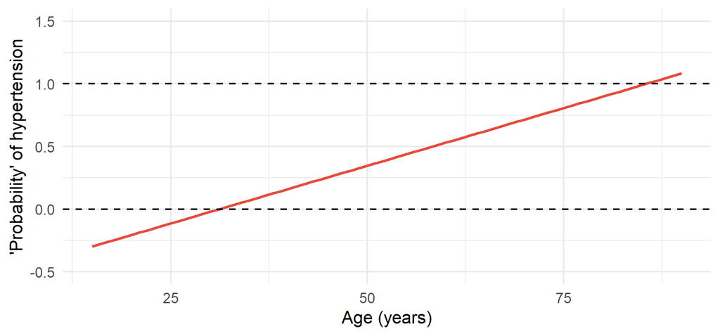

## Three problems with a straight line for a 0/1 outcome

| Problem | Why |
| --- | --- |
| **Impossible predictions** | A line is unbounded: probabilities fall below 0 or above 1 |
| **Non-constant variance** | The variance of a 0/1 outcome is p(1 − p): it depends on the mean |
| **Non-normal errors** | Residuals can only take two values per fitted value |

**Idea:** model a *transformation* of the probability that **can** take any value from −∞ to +∞ — the **log-odds**.

# Probability → odds → log-odds

## Three ways to express the same risk

odds = p ÷ (1 − p)

log-odds = ln(odds) = ln [ p ÷ (1 − p) ]

```r
tibble(probability = c(.10, .25, .32, .50, .75, .90)) |>
  mutate(odds = round(probability / (1 - probability), 2),
         `log-odds` = round(log(odds), 2))
```

```
# A tibble: 6 × 3
  probability  odds `log-odds`
        <dbl> <dbl>      <dbl>
1        0.1   0.11      -2.21
2        0.25  0.33      -1.11
3        0.32  0.47      -0.76
4        0.5   1          0
5        0.75  3          1.1
6        0.9   9          2.2
```

**Worked example:** our prevalence is 32% → odds = 0.32 ÷ 0.68 = **0.47** (“about 1 hypertensive for every 2 non-hypertensive”) → log-odds = ln 0.47 = **−0.75**.

## The logit scale is unbounded and symmetric

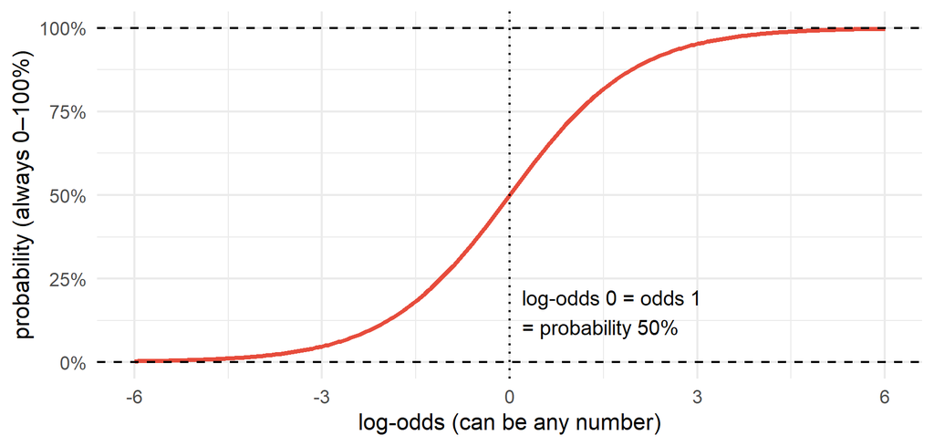

## A 2×2 example: age and hypertension

```r
tab <- ncd |> count(age50, htn_f) |> pivot_wider(names_from = htn_f, values_from = n)
tab <- tab |> mutate(risk = round(HTN / (HTN + `No HTN`), 3), odds = round(HTN / `No HTN`, 3))
tab
```

```
# A tibble: 2 × 5
  age50 `No HTN`   HTN  risk  odds
  <fct>    <int> <int> <dbl> <dbl>
1 <50 y      265    51 0.161 0.192
2 50+ y      143   141 0.496 0.986
```

```r
c(OR = tab$odds[2] / tab$odds[1], PR = tab$risk[2] / tab$risk[1]) |> round(2)
```

```
  OR   PR
5.14 3.08
```

Among **50+** the odds are **0.986**, among **<50** **0.192**: **OR = 5.1**. The prevalence ratio is only **3.1**. Keep this gap in mind.

# The model

## The logistic regression equation

logit(p) = ln [ p ÷ (1 − p) ] = β<sub>0</sub> + β<sub>1</sub>x<sub>1</sub> + β<sub>2</sub>x<sub>2</sub> + …

- The **right side** is just like linear regression
- The **left side** is the **log-odds** of the outcome
- Solve for the probability: **p = 1 ÷ (1 + exp[ −(β<sub>0</sub> + β<sub>1</sub>x<sub>1</sub> + …) ])** — always between 0 and 1
- Coefficients are estimated by **maximum likelihood**, not least squares

## Fitting it: `glm(family = binomial)`

```r
m_crude <- glm(htn ~ salt_g, data = cc, family = binomial)
summary(m_crude)$coefficients |> round(3)
```

```
            Estimate Std. Error z value Pr(>|z|)
(Intercept)   -3.648      0.400  -9.110        0
salt_g         0.376      0.049   7.665        0
```

β for salt = **0.38** — a change in **log-odds** per g/day. Not yet something a clinician can use: next we convert it.

## The S-shaped curve

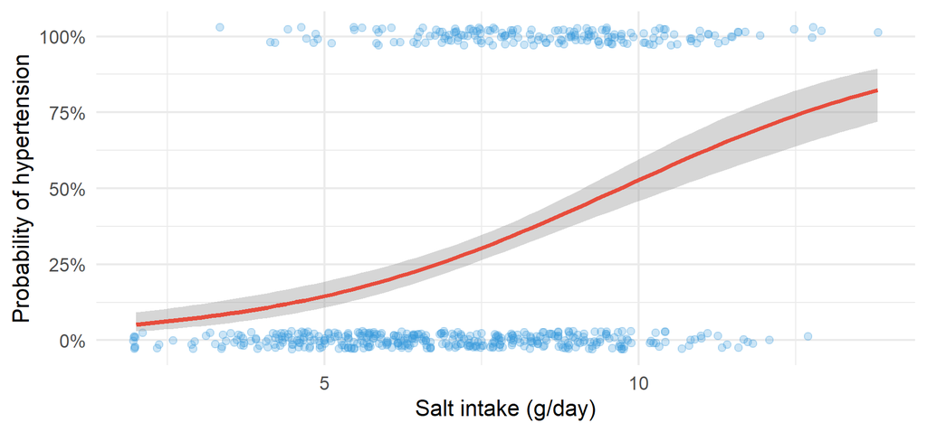

```r
ggplot(cc, aes(salt_g, htn)) +
  geom_jitter(height = .03, alpha = .25, colour = col_blue) +
  geom_smooth(method = "glm", method.args = list(family = binomial), colour = col_red, formula = y ~ x) +
  scale_y_continuous(labels = scales::percent) +
  labs(x = "Salt intake (g/day)", y = "Probability of hypertension")
```

# Why we exponentiate β

## Step 1 — the model speaks in log-odds

ln [ odds(x) ] = β<sub>0</sub> + β<sub>1</sub> x

β<sub>1</sub> is the change in **log-odds** for a **one-unit** increase in x. We want a **ratio of odds**, so compare the model at **x + 1** and at **x**.

## Step 2 — compare x + 1 with x

ln [ odds(x + 1) ] = β<sub>0</sub> + β<sub>1</sub> (x + 1) = β<sub>0</sub> + β<sub>1</sub>x + β<sub>1</sub>

ln [ odds(x + 1) ] − ln [ odds(x) ] = (β<sub>0</sub> + β<sub>1</sub>x + β<sub>1</sub>) − (β<sub>0</sub> + β<sub>1</sub>x) = **β<sub>1</sub>**

ln [ odds(x + 1) ÷ odds(x) ] = β<sub>1</sub>

OR = odds(x + 1) ÷ odds(x) = **e<sup>β<sub>1</sub></sup>**

## Step 3 — a worked number from our model

```r
b_salt <- coef(m_adj)[["salt_g"]]
c(beta = b_salt, OR_per_1g = exp(b_salt), OR_per_5g = exp(5 * b_salt), same_as = exp(b_salt)^5) |> round(3)
```

```
     beta OR_per_1g OR_per_5g   same_as
    0.214     1.238     2.914     2.914
```

- β = **0.214** → **OR per g/day = e^0.214 = 1.24**
- Per **5 g/day**: e^(5 × β) = 2.91 — ORs **multiply**, they do not add
- “Each extra 1 g/day multiplies the **odds** of hypertension by **1.24**, holding the other variables constant”

## Check it directly with two different people

```r
profile <- tibble(age = c(35, 35, 62, 62), sex = factor(c("Female", "Female", "Male", "Male"), levels(cc$sex)),
                  salt_g = c(8, 9, 8, 9), bmi = c(22, 22, 29, 29),
                  residence = factor("Rural", levels(cc$residence)), education = factor("Primary", levels(cc$education)),
                  tobacco = factor("No", levels(cc$tobacco)), alcohol = factor("No", levels(cc$alcohol)),
                  phys_act = factor("low", levels(cc$phys_act)))
p <- predict(m_adj, profile, type = "response"); odds <- p / (1 - p)
c(young_woman = odds[2] / odds[1], older_man = odds[4] / odds[3]) |> round(3)
```

```
young_woman.2   older_man.4
        1.238         1.238
```

Whatever the person’s other characteristics, 8 → 9 g/day multiplies the odds by **exactly e^β = 1.238**. The **probability** change differs by person; the **OR does not**.

## Confidence intervals: exponentiate the limits too

```r
ci_log <- confint(m_adj)["salt_g", ]                       # profile-likelihood CI on the log-odds scale
rbind(`log-odds (β)` = c(est = b_salt, ci_log), `odds ratio` = exp(c(est = b_salt, ci_log))) |> round(3)
```

```
               est 2.5 % 97.5 %
log-odds (β) 0.214 0.101  0.330
odds ratio   1.238 1.107  1.391
```

- CI for β is built on the **log scale**, where it is (approximately) symmetric
- Exponentiating each limit gives the CI for the OR: **1.24 (1.11 to 1.39)**
- Because *exp* stretches the right side more, the **OR CI is asymmetric** around the estimate

## Symmetric on the β scale, asymmetric on the OR scale

```r
bind_rows(
  tidy(m_adj, conf.int = TRUE, conf.level = .95) |> mutate(scale = "log-odds (β)"),
  tidy(m_adj, conf.int = TRUE, exponentiate = TRUE) |> mutate(scale = "odds ratio (OR)")) |>
  filter(term %in% c("sexMale", "alcoholYes", "salt_g")) |>
  mutate(scale = fct_inorder(scale), null = if_else(scale == "odds ratio (OR)", 1, 0)) |>
  ggplot(aes(estimate, term)) +
  geom_vline(aes(xintercept = null), linetype = "dashed", colour = col_red) +
  geom_pointrange(aes(xmin = conf.low, xmax = conf.high), colour = col_navy) +
  facet_wrap(~ scale, scales = "free_x") +
  labs(x = NULL, y = NULL, caption = "Dashed line = no effect: β = 0 on the left, OR = 1 on the right")
```

## Symmetric on the β scale, asymmetric on the OR scale

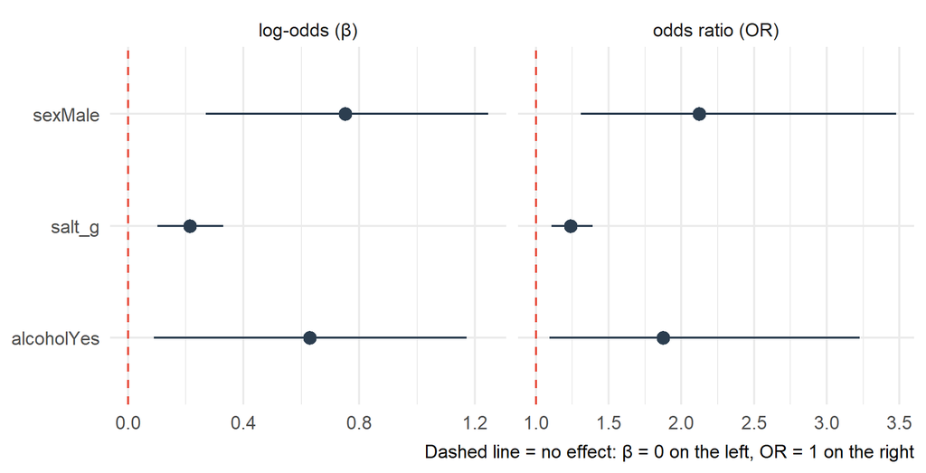

## Why OR = 1 corresponds to β = 0

e<sup>0</sup> = 1 ⇒ β = 0 ⇔ OR = 1

- OR = 1 means **no change in the odds** — no association
- A CI for the OR that **includes 1** is the same as a CI for β that **includes 0** → not significant at 5%
- OR **> 1** = higher odds; OR **< 1** = lower odds (**β > 0 / β < 0**)

## Crude vs adjusted ORs

```r
t_crude <- cc |> select(htn, salt_g, age, bmi, sex, residence, education, tobacco, alcohol, phys_act) |>
  tbl_uvregression(method = glm, y = htn, method.args = list(family = binomial), exponentiate = TRUE)
t_adj <- tbl_regression(m_adj, exponentiate = TRUE)
tbl_merge(list(t_crude, t_adj), tab_spanner = c("**Crude**", "**Adjusted**"))
```

## Crude vs adjusted ORs

| **Characteristic** | **Crude** **N** | **Crude** **OR** | **Crude** **95% CI** | **Crude** **p-value** | **Adjusted** **OR** | **Adjusted** **95% CI** | **Adjusted** **p-value** |
| --- | --- | --- | --- | --- | --- | --- | --- |
| salt_g | 551 | 1.46 | 1.33, 1.61 | <0.001 | 1.24 | 1.11, 1.39 | <0.001 |
| age | 551 | 1.11 | 1.08, 1.13 | <0.001 | 1.10 | 1.08, 1.13 | <0.001 |
| bmi | 551 | 1.18 | 1.12, 1.25 | <0.001 | 1.14 | 1.06, 1.22 | <0.001 |
| sex | 551 |  |  |  |  |  |  |
| Female |  | — | — |  | — | — |  |
| Male |  | 1.67 | 1.16, 2.41 | 0.006 | 2.12 | 1.31, 3.48 | 0.003 |
| residence | 551 |  |  |  |  |  |  |
| Urban |  | — | — |  | — | — |  |
| Rural |  | 1.03 | 0.71, 1.52 | 0.9 | 1.11 | 0.66, 1.85 | 0.7 |
| education | 551 |  |  |  |  |  |  |
| No schooling |  | — | — |  | — | — |  |
| Primary |  | 0.61 | 0.35, 1.05 | 0.075 | 0.88 | 0.46, 1.72 | 0.7 |
| Secondary |  | 0.59 | 0.33, 1.02 | 0.061 | 0.89 | 0.44, 1.78 | 0.7 |
| Graduate+ |  | 0.37 | 0.21, 0.64 | <0.001 | 0.88 | 0.43, 1.82 | 0.7 |
| tobacco | 551 |  |  |  |  |  |  |
| No |  | — | — |  | — | — |  |
| Yes |  | 1.57 | 1.07, 2.30 | 0.021 | 1.33 | 0.82, 2.13 | 0.2 |
| alcohol | 551 |  |  |  |  |  |  |
| No |  | — | — |  | — | — |  |
| Yes |  | 1.85 | 1.21, 2.82 | 0.005 | 1.88 | 1.09, 3.23 | 0.022 |
| phys_act | 551 |  |  |  |  |  |  |
| low |  | — | — |  | — | — |  |
| moderate |  | 0.99 | 0.63, 1.55 | >0.9 | 0.71 | 0.41, 1.23 | 0.2 |
| high |  | 0.99 | 0.64, 1.54 | >0.9 | 0.57 | 0.33, 0.98 | 0.041 |

Abbreviations: CI = Confidence Interval, OR = Odds Ratio

## Reading an OR, its CI and its p-value

**Salt:** adjusted OR **1.24** (95% CI 1.11–1.39), p < 0.001

- **Direction:** OR > 1 → higher odds with more salt
- **Size:** 24% higher odds per g/day; ≈ 3× per 5 g/day
- **Precision:** CI excludes 1

**Sex:** adjusted OR **2.1** for men vs women (reference)

An OR is a ratio of **odds**, not a ratio of **risks**. For a common outcome, “twice the odds” is **not** “twice as likely” (see later).

# Likelihood-based assessment

## Likelihood: how probable were the data we saw?

```r
p_hat <- c(0.8, 0.3, 0.2)       # model's predicted P(hypertension) for 3 people
y     <- c(1,   0,   0)         # what actually happened
per_person <- ifelse(y == 1, p_hat, 1 - p_hat)
per_person
```

```
[1] 0.8 0.7 0.8
```

```r
c(likelihood = prod(per_person), log_likelihood = sum(log(per_person)), deviance = -2 * sum(log(per_person))) |> round(3)
```

```
    likelihood log_likelihood       deviance
         0.448         -0.803          1.606
```

- **Likelihood** = product of the probabilities the model gave to what really happened
- **Log-likelihood** = its logarithm (easier arithmetic; always ≤ 0; **closer to 0 = better fit**)
- **Deviance** = −2 × log-likelihood (relative to a perfect model): **smaller = better fit**

## Maximum likelihood: the peak of the curve

```r
bhat <- coef(m_crude)[["salt_g"]]
prof <- tibble(b = seq(bhat - .3, bhat + .3, length.out = 100)) |>
  mutate(ll = map_dbl(b, \(b) as.numeric(logLik(glm(htn ~ 1 + offset(b * salt_g), data = cc, family = binomial)))))
ci <- confint(m_crude)["salt_g", ]

ggplot(prof, aes(b, ll)) +
  geom_line(colour = col_navy, linewidth = 1.2) +
  geom_hline(yintercept = max(prof$ll) - qchisq(.95, 1) / 2, linetype = "dashed", colour = col_red) +
  geom_vline(xintercept = c(bhat, ci), linetype = c("solid", "dotted", "dotted"), colour = col_blue) +
  labs(x = "candidate β for salt (log-odds per g/day)", y = "log-likelihood",
       caption = "Peak = maximum-likelihood estimate · red line = 1.92 below the peak → the 95% CI")
```

## Maximum likelihood: the peak of the curve

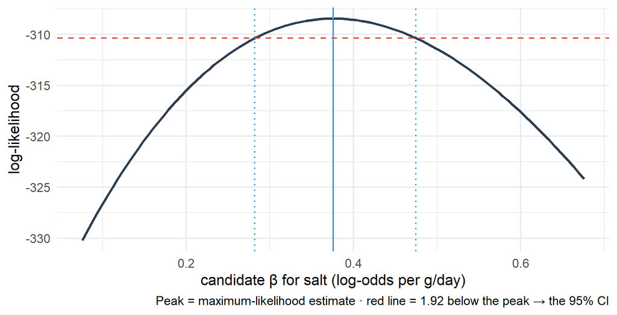

## Deviance and log-likelihood in R

```r
tibble(model = c("intercept only", "salt only", "adjusted"),
       logLik   = c(logLik(glm(htn ~ 1, binomial, cc)), logLik(m_crude), logLik(m_adj)),
       deviance = c(deviance(glm(htn ~ 1, binomial, cc)), deviance(m_crude), deviance(m_adj)),
       params   = c(1, 2, length(coef(m_adj)))) |> mutate(across(c(logLik, deviance), ~ round(.x, 1)))
```

```
# A tibble: 3 × 4
  model          logLik deviance params
  <chr>           <dbl>    <dbl>  <dbl>
1 intercept only  -344.     687.      1
2 salt only       -308.     617.      2
3 adjusted        -256.     511.     13
```

More predictors → higher log-likelihood and **lower deviance**. The question is whether the improvement is **more than chance** — that is the likelihood ratio test.

## Likelihood ratio test (LRT) for nested models

**H₀:** the extra coefficients are all zero. **Test statistic = 2 × (logLik<sub>big</sub> − logLik<sub>small</sub>)** ~ χ² with df = number of extra parameters.

```r
m_small <- glm(htn ~ age + sex, data = cc, family = binomial)
m_big   <- glm(htn ~ age + sex + salt_g + bmi + tobacco + alcohol + phys_act, data = cc, family = binomial)
anova(m_small, m_big, test = "LRT")
```

```
Analysis of Deviance Table

Model 1: htn ~ age + sex
Model 2: htn ~ age + sex + salt_g + bmi + tobacco + alcohol + phys_act
  Resid. Df Resid. Dev Df Deviance  Pr(>Chi)
1       548     568.32
2       542     511.75  6   56.574 2.228e-10 ***
---
Signif. codes:  0 '***' 0.001 '**' 0.01 '*' 0.05 '.' 0.1 ' ' 1
```

```r
lmtest::lrtest(m_small, m_big)
```

```
Likelihood ratio test

Model 1: htn ~ age + sex
Model 2: htn ~ age + sex + salt_g + bmi + tobacco + alcohol + phys_act
  #Df  LogLik Df  Chisq Pr(>Chisq)
1   3 -284.16
2   9 -255.87  6 56.574  2.228e-10 ***
---
Signif. codes:  0 '***' 0.001 '**' 0.01 '*' 0.05 '.' 0.1 ' ' 1
```

## Why LRT rather than Wald for comparing models

- **Multi-df terms**: education has 3 dummies — Wald gives 3 separate p-values; the LRT asks **“does education matter at all?”** once
- **Small samples / big effects**: Wald can be unreliable (Hauck–Donner)
- LRT is **invariant to re-parameterisation**; Wald is not

```r
drop1(m_adj, test = "LRT") |> as.data.frame() |>
  rownames_to_column("term") |> select(term, Df, AIC, LRT, `Pr(>Chi)`) |>
  mutate(across(where(is.numeric), ~ signif(.x, 3)))
```

```
        term Df AIC    LRT Pr(>Chi)
1     <none> NA 537     NA       NA
2     salt_g  1 549 14.100 1.70e-04
3        age  1 604 68.800 1.07e-16
4        bmi  1 549 13.900 1.95e-04
5        sex  1 545  9.380 2.19e-03
6  residence  1 535  0.149 7.00e-01
7  education  3 531  0.166 9.83e-01
8    tobacco  1 537  1.360 2.43e-01
9    alcohol  1 541  5.200 2.26e-02
10  phys_act  2 538  4.210 1.22e-01
```

## AIC: comparing models that are not nested

```r
m_bmi   <- glm(htn ~ age + sex + bmi,   data = cc, family = binomial)
m_waist <- glm(htn ~ age + sex + waist, data = cc, family = binomial)
AIC(m_bmi, m_waist)
```

```
        df      AIC
m_bmi    4 549.4734
m_waist  4 548.3553
```

- **AIC = −2 log-likelihood + 2 × (number of parameters)** — fit, penalised for complexity
- **Lower is better**; a difference **< 2** means essentially no preference
- Works for **non-nested** comparisons (BMI vs waist) where an LRT cannot
- Always compare on the **same rows** (watch missing data!)

# Pseudo-R²

## Three pseudo-R² measures

```r
r2(m_adj)                       # for logistic models r2() reports Tjur's R2
```

```
# R2 for Logistic Regression
  Tjur's R2: 0.292
```

```r
tibble(measure = c("McFadden", "Nagelkerke", "Tjur"),
       value   = c(r2_mcfadden(m_adj)$R2[[1]], r2_nagelkerke(m_adj)[[1]], r2_tjur(m_adj)[[1]])) |>
  mutate(value = round(value, 2))
```

```
# A tibble: 3 × 2
  measure    value
  <chr>      <dbl>
1 McFadden    0.26
2 Nagelkerke  0.38
3 Tjur        0.29
```

Three **different** numbers for one model — because they are **different things**.

## How to use (and not use) pseudo-R²

**Not**

- the same as linear R²
- “% of variance explained”
- comparable across datasets or with R² from `lm()`

**Do**

- remember their values **run low** (a McFadden of 0.2–0.4 is already a very good fit)
- report **one** descriptively, naming it
- compare models with **LRT / AIC** instead

## Tjur’s R² has a picture

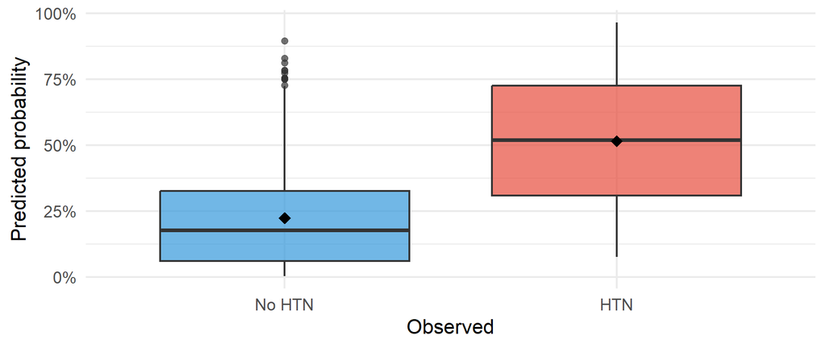

Tjur’s R² ≈ the **gap between the mean predicted probability** in people with and without the outcome. Handy — but still only descriptive.

# Calibration and discrimination

## Two different questions

**Calibration**

If the model says “30% risk”, do **about 30%** of such people actually have hypertension?

**Discrimination**

Does the model give **higher predicted risk to people who have** hypertension than to those who do not?

## Calibration plot: predicted vs observed

```r
cal <- cc |> mutate(p_hat = fitted(m_adj), decile = ntile(p_hat, 10)) |>
  group_by(decile) |> summarise(predicted = mean(p_hat), observed = mean(htn), .groups = "drop")

ggplot(cal, aes(predicted, observed)) +
  geom_abline(linetype = "dashed", colour = col_red) +
  geom_line(colour = col_navy) + geom_point(size = 3, colour = col_navy) +
  coord_equal(xlim = c(0, 1), ylim = c(0, 1)) +
  labs(x = "Mean predicted risk (decile of risk)", y = "Observed proportion with hypertension")
```

## Calibration plot: predicted vs observed

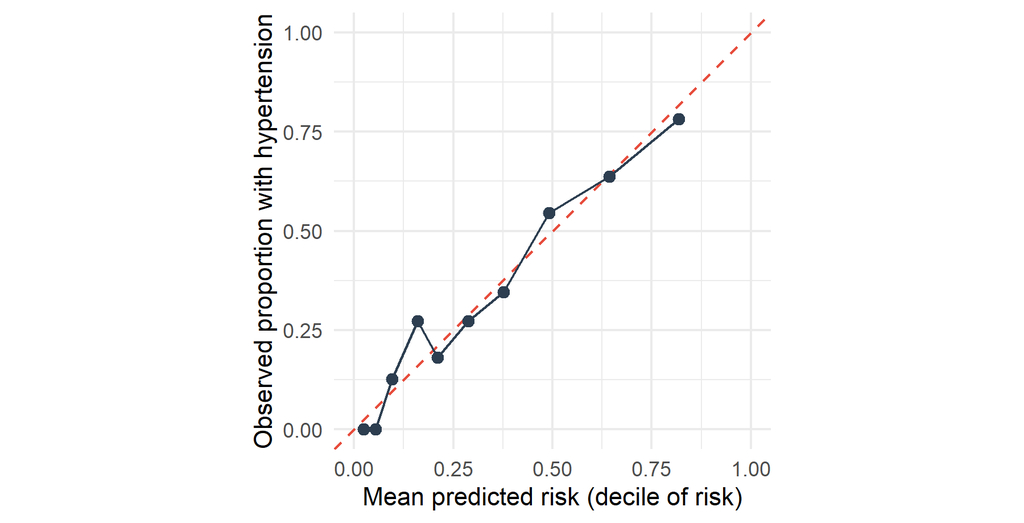

## Hosmer–Lemeshow test

```r
performance_hosmer(m_adj, n_bins = 10)
```

```
# Hosmer-Lemeshow Goodness-of-Fit Test

  Chi-squared: 12.051
           df:  8
      p-value:  0.149
```

**p > 0.05** → no evidence of poor calibration

**Limitations:** depends on the number of bins; low power in small samples, over-sensitive in huge ones; a single p-value does not show **where** the model fails. **Prefer the calibration plot.**

## ROC curve and AUC

```r
cc$p_hat <- fitted(m_adj)
roc_obj  <- roc(cc$htn, cc$p_hat, quiet = TRUE)

ggroc(roc_obj, colour = col_red, linewidth = 1.3) +
  geom_abline(intercept = 1, slope = 1, linetype = "dashed") +
  annotate("text", x = .45, y = .25, size = 6, hjust = 0,
           label = paste0("AUC = ", round(auc(roc_obj), 2))) +
  labs(x = "Specificity", y = "Sensitivity")
```

## ROC curve and AUC

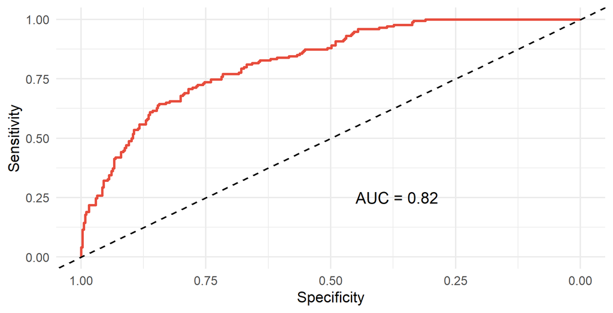

## Interpreting the AUC

```r
auc(roc_obj)
```

```
Area under the curve: 0.8244
```

```r
ci.auc(roc_obj)
```

```
95% CI: 0.7891-0.8597 (DeLong)
```

- **AUC** = probability that a **randomly chosen hypertensive** gets a **higher predicted risk** than a **randomly chosen normotensive**
- 0.5 = coin toss · 0.7–0.8 acceptable · 0.8–0.9 good · > 0.9 excellent
- Ours: **0.82** (95% CI 0.79–0.86)

## A cut-off, and a caution

```r
coords(roc_obj, "best", ret = c("threshold", "sensitivity", "specificity"), best.method = "youden") |> round(2)
```

```
  threshold sensitivity specificity
1      0.35        0.71        0.79
```

- The “best” threshold depends on purpose: **screening** (favour sensitivity) vs **confirmation** (favour specificity)
- AUC from the same data that fitted the model is **optimistic** — validate (new sample, cross-validation, bootstrap)
- Good discrimination does **not** guarantee good calibration, and vice-versa

# OR vs prevalence ratio

## The OR overstates the PR when the outcome is common

```r
risk <- tab$risk; or <- (risk[2] / (1 - risk[2])) / (risk[1] / (1 - risk[1])); pr <- risk[2] / risk[1]
c(prevalence_50plus = risk[2], prevalence_under50 = risk[1], PR = pr, OR = or) |> round(2)
```

```
 prevalence_50plus prevalence_under50                 PR                 OR
              0.50               0.16               3.08               5.13
```

“50+ year-olds have **5.1 times the odds**” is true — but “**5.1 times as likely**” is **wrong**. They are **3.1 times as likely**.

## Why: the gap grows with baseline risk

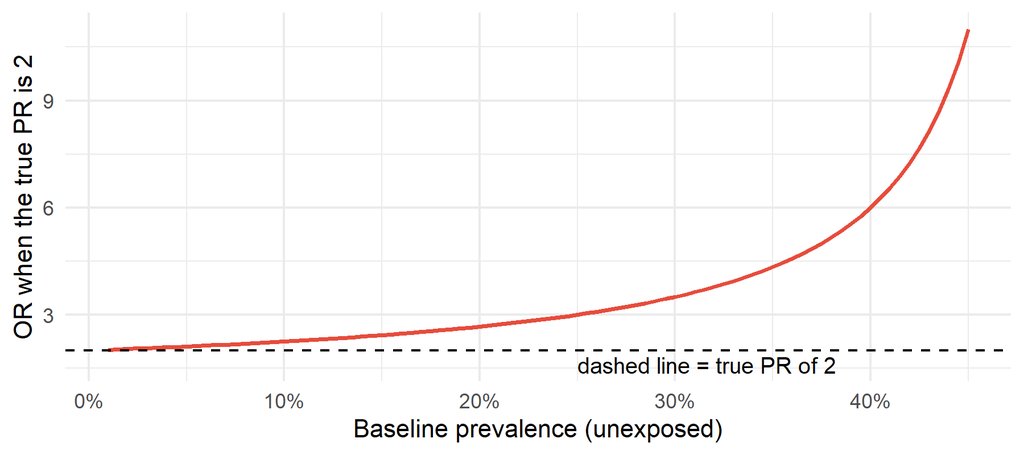

OR ≈ PR only when the outcome is **rare (< ~10%)**. With ~32% prevalence, the OR is far from the PR.

## Getting a prevalence ratio: Poisson with robust SE

```r
m_pr <- glm(htn ~ age50, data = ncd, family = poisson)
m_or <- glm(htn ~ age50, data = ncd, family = binomial)
robust_vcov <- sandwich::vcovHC(m_pr, type = "HC0")

tibble(measure  = c("OR (logistic)", "PR (Poisson, robust SE)"),
       estimate = exp(c(coef(m_or)[[2]], coef(m_pr)[[2]])),
       lower    = exp(c(confint.default(m_or)[2, 1], coefci(m_pr, vcov. = robust_vcov)[2, 1])),
       upper    = exp(c(confint.default(m_or)[2, 2], coefci(m_pr, vcov. = robust_vcov)[2, 2]))) |>
  mutate(across(where(is.numeric), ~ round(.x, 2)))
```

```
# A tibble: 2 × 4
  measure                 estimate lower upper
  <chr>                      <dbl> <dbl> <dbl>
1 OR (logistic)               5.12  3.51  7.49
2 PR (Poisson, robust SE)     3.08  2.33  4.06
```

- **Poisson with robust (sandwich) SE** gives a valid PR for a binary outcome
- **Log-binomial** (`glm(family = binomial(link = "log"))`) gives the PR directly but can **fail to converge** — try it, fall back to Poisson-robust
- Adjusted PRs work the same way (add covariates)

## 🔧 Switch to R — Lab 5

**File:** `regression-workshop/labs/lab5_logistic.R`

- `glm(family = binomial)` · exponentiated ORs and CIs · crude vs adjusted tables
- **LR test** between nested models · **AIC** · **pseudo-R²**
- **Hosmer–Lemeshow** · **ROC/AUC** · **OR vs PR**

**Time:** 45 minutes · answer Q1–Q6 in the comments

## Self-check quiz (1/6)

Why is ordinary linear regression a poor choice for a 0/1 outcome?

- It cannot include more than one predictor at a time
- Predicted probabilities can leave the 0–1 range
- It requires a much larger sample than other models
- It only accepts categorical predictor variables

## Self-check quiz (2/6)

In a logistic model β = 0.21 for salt, so e^β = 1.24. Which interpretation is correct?

- Each extra g/day raises the probability of hypertension by 24 percentage points
- Each extra g/day multiplies the odds of hypertension by 1.24, others constant
- 24% of all hypertension in the community is attributable to salt intake
- People eating more salt are 1.24 times as likely to be hypertensive

## Self-check quiz (3/6)

Which statement about pseudo-R² (McFadden, Nagelkerke, Tjur) is TRUE?

- It gives the percentage of outcome variance the model explains
- All three measures return the same value for a given model
- It is a descriptive index, not read like linear R-squared
- A value below 0.5 shows that the model is of no use

## Self-check quiz (4/6)

Hypertension prevalence is 16% under 50 and 50% at 50+ (OR ≈ 5.1, PR ≈ 3.1). Which statement is best?

- People aged 50+ are about 5 times as likely to be hypertensive
- People aged 50+ are about 3 times as likely; the OR overstates here
- The OR and the PR are identical whenever prevalence is above 10%
- The prevalence ratio can only be calculated when the disease is rare

## Self-check quiz (5/6)

A logistic model gives β = 0.69 for a binary exposure. What odds ratio is this? (nearest 0.1)

## Self-check quiz (6/6)

Two nested logistic models have log-likelihoods of −284.2 and −255.9. What is the likelihood-ratio chi-square statistic? (nearest whole number)

## Score and take-home

**Your score:**

- Logistic regression models the **log-odds**; **e^β = odds ratio**, CI limits exponentiated; **OR = 1 ⇔ β = 0**
- **Likelihood** drives assessment: compare nested models by **LRT**, others by **AIC**
- **Pseudo-R²** is descriptive, not “variance explained”
- **Calibration** (plot > Hosmer–Lemeshow) and **discrimination** (AUC) answer different questions
- For common outcomes, the **OR overstates the PR** — report the PR if you mean “times as likely”

**Next:** Session 6 — interpreting and reporting